# Projeto Final - Análise dos municípios que adotaram política de isenção de tarifa no transporte público

Thais Fernandes

Julho de 2021

1. Apresentação do objeto de estudo, recorte empírico e municípios estudados

O objeto de estudo da pesquisa a qual esse relatório se refere tem como recorte empírico o estudo de 27 cidades brasileiras que adotaram a isenção integral da tarifa do transporte público. Para a seleção dos casos foram utilizados dois critérios definidos por Klebowski (2019) para o estudo do que o autor conceitua como Free Fare Public Transport: i. A política foi implantada na maioria das redes de transporte da cidade; ii. Está disponível para a maioria dos seus usuários, durante a maior parte do tempo. Este autor define a política de isenção de tarifa no transporte público como uma forma particular de subsídio público adotada por governos locais em duas principais modalidades: parcial e completa. O foco principal dessa agenda de pesquisa é o estudo da política em seu formato completo, ou seja, o subsídio integral do valor da tarifa, sendo um dos objetivos centrais entender quais são os motivos que levam um governo local a adotar essa política.Também utilizaremos o termo FFTP para se referir a política, abreviação de Free Fare Public Transport, também seguindo Klebowski (2019).Esse relatório é uma análise exploratória de dados públicos a respeito dos municípios estudados. Abaixo há uma tabela com o nome dos municípios, data de implementação da política e unidade federativa, essas informações foram coletadas, além de pesquisa própria, da dissertação de mestrado de Marijke Vermander (2021),“Exploring Fare-Free Public Transport in Brasil: Rationales and characteristics of Tarifa Zero policies in small Brazilian municipalitie”.

| UF | Município | Ano da Implementação |
| --- | --- | --- |
| CE | Aquiraz | 2018 |
| CE | Eusébio | 2010 |
| MG | Abaeté | 1997 |
| MG | Arceburgo | 2019 |
| MG | Campo Belo | 2019 |
| MG | Cláudio | 2021 |
| MG | Itatiaiuçu | 2015 |
| MG | Monte Carmelo | 1994 |
| MG | Muzambinho | 2011 |
| RJ | Maricá | 2013 |
| RJ | Silva Jardim | 2014 |
| SP | Agudos | 2003 |
| SP | Cerquilho | 2020 |
| SP | Dourado | 2014 |
| SP | Holambra | 2010 |
| SP | Macatuba | 2004 |
| SP | Morungaba | 2019 |
| SP | Pirapora do Bom Jesus | 2020 |
| SP | Potirendaba | 1998 |
| SP | Vargem Grande Paulista | 2019 |
| PR | Faxinal | 2001 |
| PR | Ivaiporã | 2001 |
| PR | Pitanga | 2012 |
| PR | Wenceslau Braz | 2008 |
| RS | Pedro Osório | 2018 |
| GO | Anicuns | 2014 |
| GO | Aruanã | 2008 |

2.Localização dos municípios

O mapa abaixo nos mostra a localização das cidades, os pontos representam os municípios:

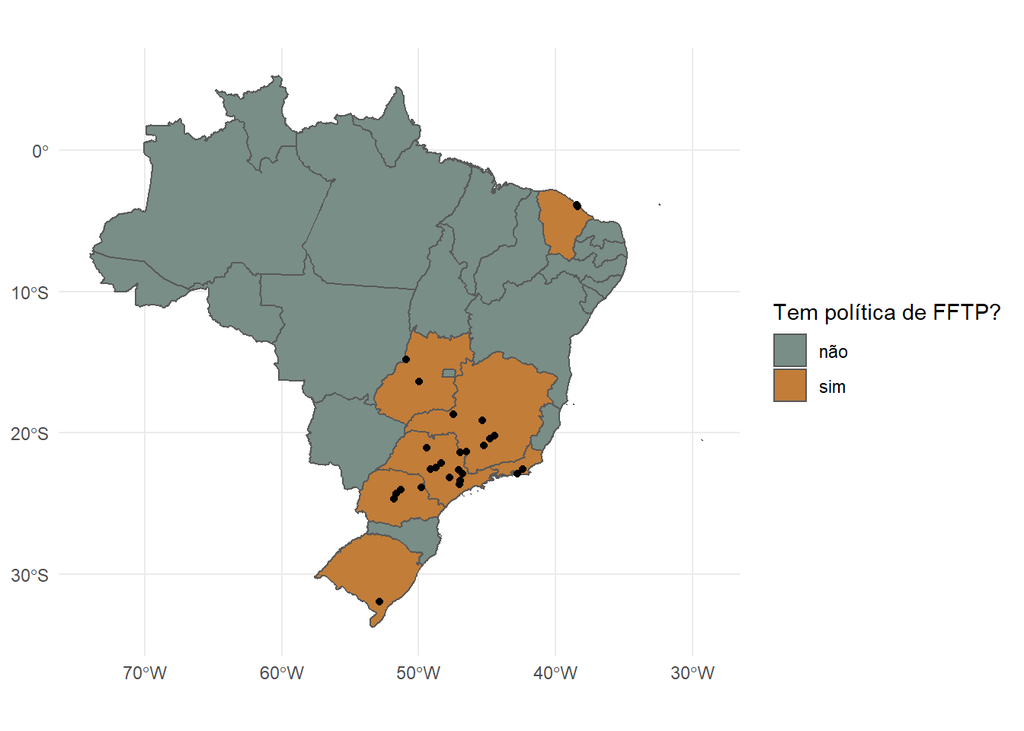

Essa tabela nos mostra a região dos municípios, através dela podemos visualizar que mais da metade (cerca de 66%) deles estão localizados no sudeste do país. Sabemos que o nordeste é a região do Brasil com mais municípios, seguido da região sudeste, no entanto, o nordeste só tem 2 municípios com FFTP.

| Região | Qtd. de Municípios |
| --- | --- |
| Sudeste | 18 |
| Sul | 5 |
| Centro-Oeste | 2 |
| Nordeste | 2 |

Dos 27 estados brasileiros, sete possuem algum município que implementou FFTP, Minas Gerais é o estado com mais municípios no Brasil mas o segundo com mais cidades com FFT, e São Paulo é o segundo com mais municípios e no entando o estado com mais cidades que adotaram a política.

| UF | Qtd. de Municípios |
| --- | --- |
| SP | 9 |
| MG | 7 |
| PR | 4 |
| CE | 2 |
| GO | 2 |
| RJ | 2 |
| RS | 1 |

3.Dados populacionais

A média populacional desses municípios é 31 mil habitantes, sendo que há quantidades bem discrepantes, como um máximo de pouco mais de 160 mil, como é o caso de Maricá no Rio de Janeiro, e um mínimo de 7 mil habitantes em Pedro Osório no Rio Grande do Sul (IBGE, 2020).Abaixo podemos visualizar a quantidade de municípios por classe populacional,cerca de 70% dos municípios possuem entre 10 e 50 mil habitante ao passo que não há nenhum município com mais de 500 mil habitantes que tenha adotado a política de FFTP.

| Classe Populacional | Munic.com FFTP | Munic.sem FFTP |
| --- | --- | --- |
| 20.000 Até 50.000 | 10 | 1090 |
| 10.000 Até 20.000 | 9 | 1336 |
| 50.000 Até 100.000 | 4 | 345 |
| 5.000 Até 10.000 | 3 | 1196 |
| 100.000 Até 500.000 | 1 | 275 |

4.Ano de Implementação da Política de FFTP

Quase 70% dos municípios que adotaram FFTP o fizeram depois de 2010, seguindo uma tendência mundial já observada por Klebowski (2019), no entanto, como mostrado na tabela inicial deste relatório, há três casos de municípios que adotaram a política ainda nos anos 1990, como Monte Carmelo (MG) que adotou em 1994, Potirendaba (SP) em 1998 e Abaeté (MG)em 1997.

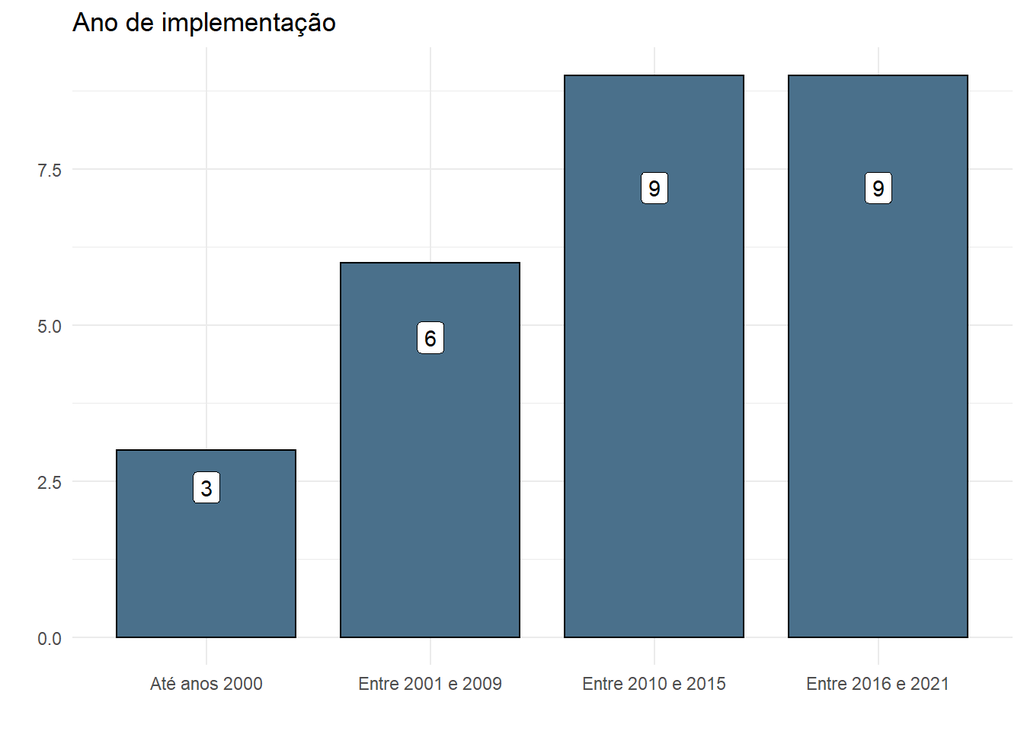

4. Taxa de Urbanização